# Directional changes in AGB dynamics in tropical forests: a pantropical test. Tutorial

July 2017

### Rationale

Understanding how tropical forests (TF) are responding to ongoing climate change is a major challenge to model future global carbon cycle. Analysis of standardized forest inventories suggest an overall increase of 0.36 Mg C ha^-1 yr^-1 (CI = 0.29-0.66) (Muller-Landau et al. 2014). However, the plausible causes of this increase and its consistency in both space and time remain much debated. Detecting on-the-ground changes in forest carbon stocks remain challenging due to known caveats, such as limited spatial and temporal coverages, inaccurate estimates (i.e. minimal DBH > 10 cm), measurement errors and correction procedures or inherent disturbance-recovery dynamics. The CTFS-ForestGEO network represents a unique opportunity to address these issues and investigate long-term dynamics of TF. Using the CTFS-ForestGEO will circumvent some inherent limitations listed above.

Using consecutive and standardized forest inventories, we propose to investigate whether there is a directional change in carbon fluxes in large plots (size > 10 ha) across CTFS-ForestGEO plots. In the present study, we propose to test three alternative hypotheses that could explain an apparent increase in TF. Enhanced biomass stocks may be due to enhanced biomass accumulation, due to boosted growth or lowered mortality (“speed up” hypothesis); or due to extended succession cycle, where biomass accumulation after gap disturbance last longer before being reset (“extended succession” hypothesis). Alternatively, ordinary succession after disturbance would generate similar pattern, and represent a null hypothesis or non-global change hypothesis.

To properly account for the gap dynamic, plots are split into 6.25, 10, 12.5-m width subplots, aiming to quantify how local biomass fluxes (i.e., productivity, loss and net change) vary with initial biomass (an indicator of stand structure) for each census interval, and to compare these patterns across census intervals. This approach enables gap dynamics to be captured (Muller-Landau et al. 2014), and investigate temporal changes in AGB dynamic while controlling for natural succession.

### Goal of this tutorial

This tutorial provides you with step-by-step instruction to run the analaysis at your site. Note that most sites have peculiar codes that may result in malfunction of the scripts. If you get a message error, please contact: er.rutishauser@gmail.com .**Scripts are provided without any warranty and results shall be interpreted with caution.**

For illustration purpose, the analysis is carried on at BCI with publicly available data from 1985 to 2005. To get most accurate biomass estimates, ‘stem’ data are preferred, but the analysis can be run on ‘tree data’(i.e. full1.Rdata).

#### STEP 1: Data formating and crude correction

Your data (**inventories + ssp.table**) should be located in the “/data/” folder, with censuses classified in increasing chronological order, such as “stem1.Rdata”, “stem2.Rdata”, … (Figure below)

[figure not shown]

** You can download the RStudio project at the following [link](https://github.com/ervanSTRI/biomass_fluxes_BCI)** , then dowload the zip file as shown below:

[figure not shown]

The main function used here is qaqc.data() that has the following arguments:

- **site** :the full name of you site (here it will be “barro colorado island”)
- **stem** : if TRUE you are working with multi-stem data, if FALSE with tree data (‘full’ format)
- **taper.correction** : if you want to apply Cushman’s taper correction (Cushman et al. 2014), when POM has changed (only avaialbe for BCI at the moment)
- **fill_missing** : if TRUE, missing values (NA) are filled up by averaging among closest in time measures.
- **palm** : if TRUE, AGB of species belonging to the Arecacea family is computed with a family wise allometric model (Goodman et al. 2013)
- **strangler** : if TRUE, strangler figs are flagged
- **maxrel** : the threshold above which tree productivity is flagged as anormalous. It is the percentage of mean annual productivity per hectare computed at your site. We use a default value of 20 (%).
- **draw.graph** : if TRUE, trees flagged with abnormalously high/low productivity are plotted (might be time consuming)
- **output.errors** : if TRUE, a csv with abnormalous trees is produced

**!! Might be time consuming for large datasets !!**

```r
# Declare you site here:
SITE <- "barro colorado island"
```

```r
# load necessary information


system.time(DF <- qaqc.data(site = SITE, stem = T,
    taper.correction = T, fill_missing = T, palm = T,
    strangler = T, maxrel = 20, draw.graph = T, output.errors = T))
```

#### STEP 2: Create quadrats

Once **Step 1** has been done once, you can jump to **step 2** directly. The data set is divided in quadrat of size defined by “grid_size”.

```r
path_folder <- dirname(getwd())
DF <- LOAD(paste0(path_folder, "/output/", SITE, "_census_intervals.Rdata"))
YEAR <- levels(factor(DF$year))

grid.size = 10
area = (grid.size^2)/(10000)
DF <- create.quadrats(DF, grid.size)
DF <- DF[!is.na(quadrat)]

QUAD <- DF[, .(agb1 = sum(agba1, na.rm = T)/area, agb2 = sum(agba2[code !=
    "D"], na.rm = T)/area, int = mean(int, na.rm = T),
    hom = max(dHOM, na.rm = T), prodg = sum(prod.g,
        na.rm = T)/area, prodr = sum(prod.r, na.rm = T)/area,
    loss = sum(loss, na.rm = T)/(area), dens1 = length(dbh1[!code %in%
        c("R")])/area, dens2 = length(dbh2[code !=
        "D"])/area, Ndead = length(dbh1[code == "D"])/area,
    Nrec = length(dbh2[code == "R"])/area, error.prod = any(error !=
        0), error.loss = sum(error.loss), ficus = sum(ficus)),
    by = c("quadrat", "year")]
QUAD[, `:=`(lLOSS, log10(loss))]
QUAD[, `:=`(lAGB, log10(agb1))]
QUAD[, `:=`(lAGB2, log10(agb2))]
QUAD[, `:=`(prod, (prodg + prodr))]
QUAD[, `:=`(NC, prod - loss)]
QUAD[, `:=`(dN, (dens2 - dens1)/int)]
QUAD[, `:=`(Ndead, Ndead/int)]
QUAD[, `:=`(Nrec, Nrec/int)]
QUAD[, `:=`(drop, as.numeric(0))]
QUAD <- within(QUAD, drop[hom != 0 | ficus != 0] <- 1)  # quadrats to be dropped out
```

#### STEP 3: Create outputs

##### Graph 1: Biomass fluxes (productivity, loss and net change) by census interval at 50-ha plot level

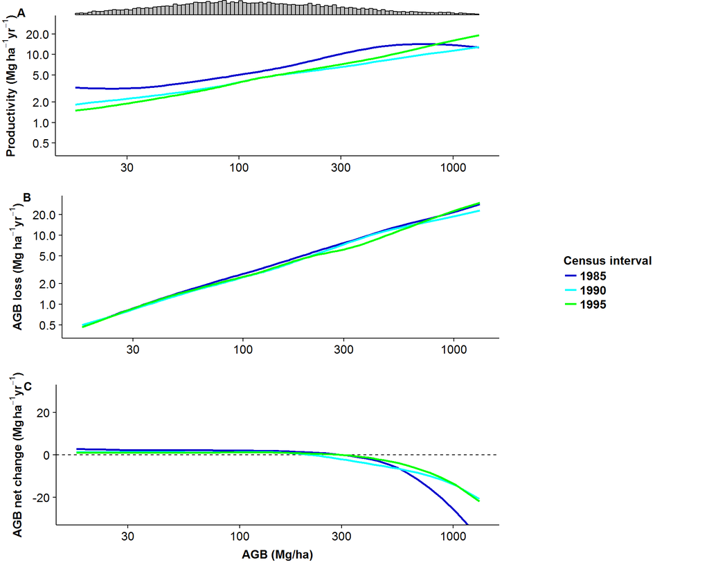

##### Computation of boostrap confidence intervals

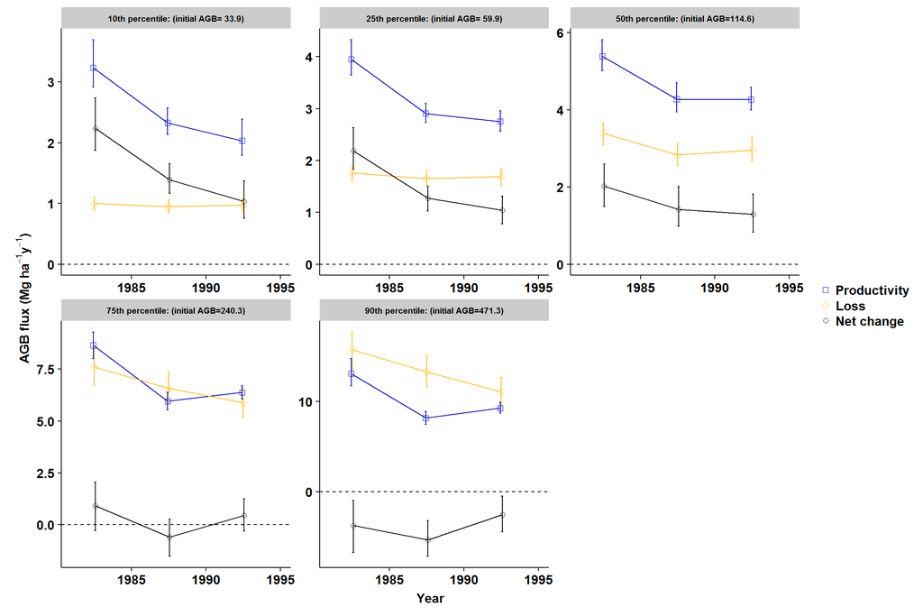

```r
CI <- data.frame(year = NA, var = NA, lAGB = NA, y = NA,
    lw = NA, up = NA)
Nboot <- 500
set.seed(20)
Xrange = as.numeric(quantile(QUAD[drop == 0, lAGB],
    seq(0.01, 1, 0.01)))  # 100 values to estimate the smooth spline

boot <- list(matrix(NA, Nboot, 100 * length(YEAR)),
    matrix(NA, Nboot, 100 * length(YEAR)), matrix(NA,
        Nboot, 100 * length(YEAR)))

system.time(for (i in 1:Nboot) {
    A <- QUAD[drop == 0 & error.prod == 0, .SD[sample(.N,
        .N, replace = T)], by = year]
    boot[[1]][i, ] <- A[, .(loess.function(.SD, prod,
        Xrange)), by = year][order(year)]$V1
    boot[[2]][i, ] <- A[, .(loess.function(.SD, NC,
        Xrange)), by = year][order(year)]$V1

    A1 <- QUAD[error.loss == 0, .SD[sample(.N, .N,
        replace = T)], by = year]
    boot[[3]][i, ] <- A1[, .(loess.function(.SD, loss,
        Xrange)), by = year][order(year)]$V1
})
boot.lw <- lapply(boot, function(Y) apply(Y, 2, function(X) quantile(X,
    0.025)))
boot.mid <- lapply(boot, function(Y) apply(Y, 2, function(X) quantile(X,
    0.5)))
boot.up <- lapply(boot, function(Y) apply(Y, 2, function(X) quantile(X,
    0.975)))
CI <- data.table(year = rep(YEAR, each = 100), var = rep(c("prod",
    "nc", "loss"), each = 100 * length(YEAR)), lAGB = rep(Xrange,
    length(YEAR)), y = unlist(boot.mid), lw = unlist(boot.lw),
    up = unlist(boot.up))
save(CI, file = paste0(path_folder, "/output/", SITE,
    "_CI_fluxes.Rdata"))
```